# Risk Factor Analysis

## Outcome Variable

**Outcome Variable:** stunted

## Predictor Variables

**Intervention Variable:** perdiar24

**Adjustment Set:**

- arm
- sex
- meducyrs
- feducyrs
- hhwealth_quart
- hfoodsec
- vagbrth
- hdlvry
- W_birthwt
- W_birthlen
- single
- W_nrooms
- month
- brthmon
- impfloor
- impsan
- safeh20
- delta_meducyrs
- delta_feducyrs
- delta_hhwealth_quart
- delta_hfoodsec
- delta_vagbrth
- delta_hdlvry
- delta_W_birthwt
- delta_W_birthlen
- delta_single
- delta_W_nrooms
- delta_month
- delta_brthmon
- delta_impfloor
- delta_impsan
- delta_safeh20

## Stratifying Variables

The analysis was stratified on these variable(s):

- agecat
- studyid
- country

## Data Summary

| agecat | studyid | country | perdiar24 | stunted | n_cell | n |
| --- | --- | --- | --- | --- | --- | --- |
| Birth | ki0047075b-MAL-ED | BANGLADESH | 0% | 0 | 13 | 231 |
| Birth | ki0047075b-MAL-ED | BANGLADESH | 0% | 1 | 5 | 231 |
| Birth | ki0047075b-MAL-ED | BANGLADESH | (0%, 5%] | 0 | 112 | 231 |
| Birth | ki0047075b-MAL-ED | BANGLADESH | (0%, 5%] | 1 | 19 | 231 |
| Birth | ki0047075b-MAL-ED | BANGLADESH | >5% | 0 | 62 | 231 |
| Birth | ki0047075b-MAL-ED | BANGLADESH | >5% | 1 | 20 | 231 |
| Birth | ki0047075b-MAL-ED | BRAZIL | 0% | 0 | 31 | 65 |
| Birth | ki0047075b-MAL-ED | BRAZIL | 0% | 1 | 3 | 65 |
| Birth | ki0047075b-MAL-ED | BRAZIL | (0%, 5%] | 0 | 23 | 65 |
| Birth | ki0047075b-MAL-ED | BRAZIL | (0%, 5%] | 1 | 6 | 65 |
| Birth | ki0047075b-MAL-ED | BRAZIL | >5% | 0 | 2 | 65 |
| Birth | ki0047075b-MAL-ED | BRAZIL | >5% | 1 | 0 | 65 |
| Birth | ki0047075b-MAL-ED | INDIA | 0% | 0 | 4 | 47 |
| Birth | ki0047075b-MAL-ED | INDIA | 0% | 1 | 1 | 47 |
| Birth | ki0047075b-MAL-ED | INDIA | (0%, 5%] | 0 | 27 | 47 |
| Birth | ki0047075b-MAL-ED | INDIA | (0%, 5%] | 1 | 6 | 47 |
| Birth | ki0047075b-MAL-ED | INDIA | >5% | 0 | 6 | 47 |
| Birth | ki0047075b-MAL-ED | INDIA | >5% | 1 | 3 | 47 |
| Birth | ki0047075b-MAL-ED | NEPAL | 0% | 0 | 2 | 27 |
| Birth | ki0047075b-MAL-ED | NEPAL | 0% | 1 | 0 | 27 |
| Birth | ki0047075b-MAL-ED | NEPAL | (0%, 5%] | 0 | 19 | 27 |
| Birth | ki0047075b-MAL-ED | NEPAL | (0%, 5%] | 1 | 0 | 27 |
| Birth | ki0047075b-MAL-ED | NEPAL | >5% | 0 | 4 | 27 |
| Birth | ki0047075b-MAL-ED | NEPAL | >5% | 1 | 2 | 27 |
| Birth | ki0047075b-MAL-ED | PERU | 0% | 0 | 21 | 233 |
| Birth | ki0047075b-MAL-ED | PERU | 0% | 1 | 0 | 233 |
| Birth | ki0047075b-MAL-ED | PERU | (0%, 5%] | 0 | 78 | 233 |
| Birth | ki0047075b-MAL-ED | PERU | (0%, 5%] | 1 | 11 | 233 |
| Birth | ki0047075b-MAL-ED | PERU | >5% | 0 | 108 | 233 |
| Birth | ki0047075b-MAL-ED | PERU | >5% | 1 | 15 | 233 |

[output cut: 234 more lines]

The following strata were considered:

- agecat: 24 months, studyid: ki0047075b-MAL-ED, country: BANGLADESH
- agecat: 24 months, studyid: ki0047075b-MAL-ED, country: BRAZIL
- agecat: 24 months, studyid: ki0047075b-MAL-ED, country: INDIA
- agecat: 24 months, studyid: ki0047075b-MAL-ED, country: NEPAL
- agecat: 24 months, studyid: ki0047075b-MAL-ED, country: PERU
- agecat: 24 months, studyid: ki0047075b-MAL-ED, country: SOUTH AFRICA
- agecat: 24 months, studyid: ki0047075b-MAL-ED, country: TANZANIA, UNITED REPUBLIC OF
- agecat: 24 months, studyid: ki1000109-EE, country: PAKISTAN
- agecat: 24 months, studyid: ki1017093-NIH-Birth, country: BANGLADESH
- agecat: 24 months, studyid: ki1017093b-PROVIDE, country: BANGLADESH
- agecat: 24 months, studyid: ki1017093c-NIH-Crypto, country: BANGLADESH
- agecat: 24 months, studyid: ki1114097-CMIN, country: BANGLADESH
- agecat: 24 months, studyid: ki1114097-CONTENT, country: PERU
- agecat: 24 months, studyid: kiGH5241-JiVitA-4, country: BANGLADESH
- agecat: 6 months, studyid: ki0047075b-MAL-ED, country: BANGLADESH
- agecat: 6 months, studyid: ki0047075b-MAL-ED, country: BRAZIL
- agecat: 6 months, studyid: ki0047075b-MAL-ED, country: INDIA
- agecat: 6 months, studyid: ki0047075b-MAL-ED, country: NEPAL
- agecat: 6 months, studyid: ki0047075b-MAL-ED, country: PERU
- agecat: 6 months, studyid: ki0047075b-MAL-ED, country: SOUTH AFRICA
- agecat: 6 months, studyid: ki0047075b-MAL-ED, country: TANZANIA, UNITED REPUBLIC OF
- agecat: 6 months, studyid: ki1000109-EE, country: PAKISTAN
- agecat: 6 months, studyid: ki1000304b-SAS-FoodSuppl, country: INDIA
- agecat: 6 months, studyid: ki1017093-NIH-Birth, country: BANGLADESH
- agecat: 6 months, studyid: ki1017093b-PROVIDE, country: BANGLADESH
- agecat: 6 months, studyid: ki1017093c-NIH-Crypto, country: BANGLADESH
- agecat: 6 months, studyid: ki1112895-Guatemala BSC, country: GUATEMALA
- agecat: 6 months, studyid: ki1114097-CMIN, country: BANGLADESH
- agecat: 6 months, studyid: ki1114097-CONTENT, country: PERU
- agecat: 6 months, studyid: kiGH5241-JiVitA-4, country: BANGLADESH
- agecat: Birth, studyid: ki0047075b-MAL-ED, country: BANGLADESH
- agecat: Birth, studyid: ki0047075b-MAL-ED, country: BRAZIL
- agecat: Birth, studyid: ki0047075b-MAL-ED, country: INDIA
- agecat: Birth, studyid: ki0047075b-MAL-ED, country: NEPAL
- agecat: Birth, studyid: ki0047075b-MAL-ED, country: PERU
- agecat: Birth, studyid: ki0047075b-MAL-ED, country: SOUTH AFRICA
- agecat: Birth, studyid: ki0047075b-MAL-ED, country: TANZANIA, UNITED REPUBLIC OF
- agecat: Birth, studyid: ki1000109-EE, country: PAKISTAN
- agecat: Birth, studyid: ki1017093-NIH-Birth, country: BANGLADESH
- agecat: Birth, studyid: ki1017093b-PROVIDE, country: BANGLADESH
- agecat: Birth, studyid: ki1017093c-NIH-Crypto, country: BANGLADESH
- agecat: Birth, studyid: ki1114097-CMIN, country: BANGLADESH
- agecat: Birth, studyid: ki1114097-CONTENT, country: PERU
- agecat: Birth, studyid: kiGH5241-JiVitA-4, country: BANGLADESH

### Dropped Strata

Some strata were dropped due to rare outcomes:

- agecat: Birth, studyid: ki0047075b-MAL-ED, country: BRAZIL
- agecat: Birth, studyid: ki0047075b-MAL-ED, country: INDIA
- agecat: Birth, studyid: ki0047075b-MAL-ED, country: NEPAL
- agecat: Birth, studyid: ki0047075b-MAL-ED, country: PERU
- agecat: Birth, studyid: ki0047075b-MAL-ED, country: SOUTH AFRICA
- agecat: Birth, studyid: ki0047075b-MAL-ED, country: TANZANIA, UNITED REPUBLIC OF
- agecat: Birth, studyid: ki1000109-EE, country: PAKISTAN
- agecat: Birth, studyid: ki1017093b-PROVIDE, country: BANGLADESH
- agecat: Birth, studyid: ki1114097-CMIN, country: BANGLADESH
- agecat: Birth, studyid: ki1114097-CONTENT, country: PERU
- agecat: 6 months, studyid: ki0047075b-MAL-ED, country: BANGLADESH
- agecat: 6 months, studyid: ki0047075b-MAL-ED, country: BRAZIL
- agecat: 6 months, studyid: ki0047075b-MAL-ED, country: INDIA
- agecat: 6 months, studyid: ki0047075b-MAL-ED, country: NEPAL
- agecat: 6 months, studyid: ki0047075b-MAL-ED, country: PERU
- agecat: 6 months, studyid: ki0047075b-MAL-ED, country: SOUTH AFRICA
- agecat: 6 months, studyid: ki0047075b-MAL-ED, country: TANZANIA, UNITED REPUBLIC OF
- agecat: 6 months, studyid: ki1000109-EE, country: PAKISTAN
- agecat: 6 months, studyid: ki1017093b-PROVIDE, country: BANGLADESH
- agecat: 6 months, studyid: ki1114097-CMIN, country: BANGLADESH
- agecat: 6 months, studyid: ki1114097-CONTENT, country: PERU
- agecat: 24 months, studyid: ki0047075b-MAL-ED, country: BANGLADESH
- agecat: 24 months, studyid: ki0047075b-MAL-ED, country: BRAZIL
- agecat: 24 months, studyid: ki0047075b-MAL-ED, country: INDIA
- agecat: 24 months, studyid: ki0047075b-MAL-ED, country: NEPAL
- agecat: 24 months, studyid: ki0047075b-MAL-ED, country: PERU
- agecat: 24 months, studyid: ki0047075b-MAL-ED, country: SOUTH AFRICA
- agecat: 24 months, studyid: ki0047075b-MAL-ED, country: TANZANIA, UNITED REPUBLIC OF
- agecat: 24 months, studyid: ki1000109-EE, country: PAKISTAN
- agecat: 24 months, studyid: ki1017093-NIH-Birth, country: BANGLADESH
- agecat: 24 months, studyid: ki1017093b-PROVIDE, country: BANGLADESH
- agecat: 24 months, studyid: ki1114097-CMIN, country: BANGLADESH
- agecat: 24 months, studyid: ki1114097-CONTENT, country: PERU

## Methods Detail

We’re interested in the causal parameters $E[Y_a]$ for all values of $a \in \mathcal{A}$. These parameters represent the mean outcome if, possibly contrary to fact, we intervened to set all units to have $A=a$. Under the randomization and positivity assumptions, these are identified by the statistical parameters $\psi_a=E_W[E_{Y|A,W}(Y|A=a,W)]$. In addition, we’re interested in the mean of $Y$, $E[Y]$ under no intervention (the observed mean). We will estimate these parameters by using SuperLearner to fit the relevant likelihood factors – $E_{Y|A,W}(Y|A=a,W)$ and $p(A=a|W)$, and then updating our likelihood fit using a joint TMLE.

For unadjusted analyses ($W=\{\}$), initial likelihoods were estimated using Lrnr_glm to estimate the simple $E(Y|A)$ and Lrnr_mean to estimate $p(A)$. For adjusted analyses, a small library containing Lrnr_glmnet, Lrnr_xgboost, and Lrnr_mean was used.

Having estimated these parameters, we will then use the delta method to estimate relative risks and attributable risks relative to a prespecified baseline level of $A$.

# Results Detail

## Results Plots

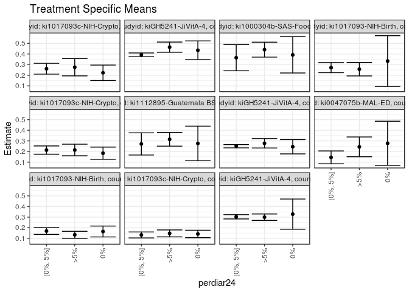

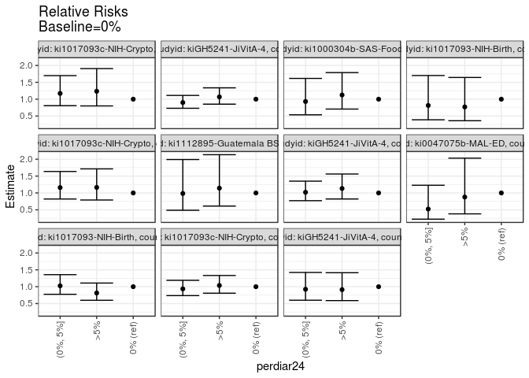

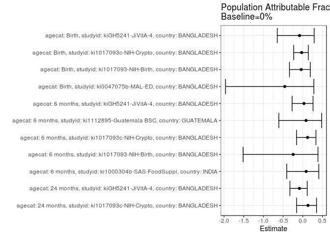

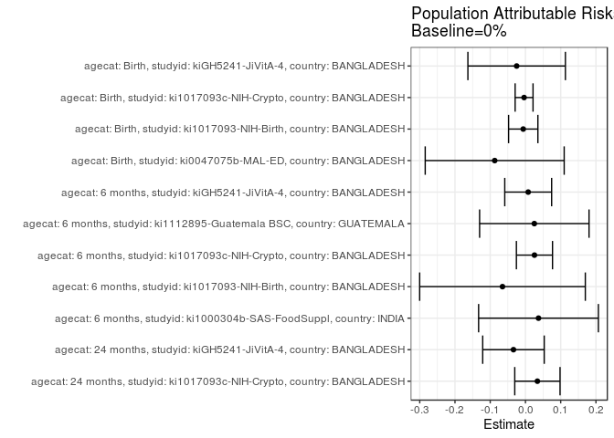

## Results Table

### Parameter: TSM

| agecat | studyid | country | intervention_level | baseline_level | estimate | ci_lower | ci_upper |
| --- | --- | --- | --- | --- | --- | --- | --- |
| Birth | ki0047075b-MAL-ED | BANGLADESH | 0% | NA | 0.2777778 | 0.0704115 | 0.4851440 |
| Birth | ki0047075b-MAL-ED | BANGLADESH | (0%, 5%] | NA | 0.1450382 | 0.0846059 | 0.2054705 |
| Birth | ki0047075b-MAL-ED | BANGLADESH | >5% | NA | 0.2439024 | 0.1507530 | 0.3370519 |
| Birth | ki1017093-NIH-Birth | BANGLADESH | 0% | NA | 0.1650026 | 0.1137337 | 0.2162715 |
| Birth | ki1017093-NIH-Birth | BANGLADESH | (0%, 5%] | NA | 0.1691526 | 0.1373770 | 0.2009282 |
| Birth | ki1017093-NIH-Birth | BANGLADESH | >5% | NA | 0.1341945 | 0.1014408 | 0.1669482 |
| Birth | ki1017093c-NIH-Crypto | BANGLADESH | 0% | NA | 0.1419121 | 0.1067804 | 0.1770439 |
| Birth | ki1017093c-NIH-Crypto | BANGLADESH | (0%, 5%] | NA | 0.1327345 | 0.1046973 | 0.1607717 |
| Birth | ki1017093c-NIH-Crypto | BANGLADESH | >5% | NA | 0.1470867 | 0.1144195 | 0.1797540 |
| Birth | kiGH5241-JiVitA-4 | BANGLADESH | 0% | NA | 0.3285863 | 0.1864424 | 0.4707303 |
| Birth | kiGH5241-JiVitA-4 | BANGLADESH | (0%, 5%] | NA | 0.3033901 | 0.2832319 | 0.3235482 |
| Birth | kiGH5241-JiVitA-4 | BANGLADESH | >5% | NA | 0.2997590 | 0.2694497 | 0.3300682 |
| 6 months | ki1000304b-SAS-FoodSuppl | INDIA | 0% | NA | 0.3919521 | 0.2211777 | 0.5627266 |
| 6 months | ki1000304b-SAS-FoodSuppl | INDIA | (0%, 5%] | NA | 0.3650249 | 0.2418397 | 0.4882102 |
| 6 months | ki1000304b-SAS-FoodSuppl | INDIA | >5% | NA | 0.4408391 | 0.3704849 | 0.5111933 |
| 6 months | ki1017093-NIH-Birth | BANGLADESH | 0% | NA | 0.3333333 | 0.0945517 | 0.5721150 |
| 6 months | ki1017093-NIH-Birth | BANGLADESH | (0%, 5%] | NA | 0.2713864 | 0.2240064 | 0.3187665 |
| 6 months | ki1017093-NIH-Birth | BANGLADESH | >5% | NA | 0.2568306 | 0.1934736 | 0.3201876 |
| 6 months | ki1017093c-NIH-Crypto | BANGLADESH | 0% | NA | 0.1842645 | 0.1270765 | 0.2414525 |
| 6 months | ki1017093c-NIH-Crypto | BANGLADESH | (0%, 5%] | NA | 0.2135165 | 0.1745146 | 0.2525184 |
| 6 months | ki1017093c-NIH-Crypto | BANGLADESH | >5% | NA | 0.2144214 | 0.1599723 | 0.2688705 |
| 6 months | ki1112895-Guatemala BSC | GUATEMALA | 0% | NA | 0.2758621 | 0.1129200 | 0.4388041 |
| 6 months | ki1112895-Guatemala BSC | GUATEMALA | (0%, 5%] | NA | 0.2714286 | 0.1670791 | 0.3757781 |
| 6 months | ki1112895-Guatemala BSC | GUATEMALA | >5% | NA | 0.3150000 | 0.2505146 | 0.3794854 |
| 6 months | kiGH5241-JiVitA-4 | BANGLADESH | 0% | NA | 0.2449856 | 0.1776653 | 0.3123058 |
| 6 months | kiGH5241-JiVitA-4 | BANGLADESH | (0%, 5%] | NA | 0.2497572 | 0.2345097 | 0.2650047 |
| 6 months | kiGH5241-JiVitA-4 | BANGLADESH | >5% | NA | 0.2773905 | 0.2331385 | 0.3216425 |
| 24 months | ki1017093c-NIH-Crypto | BANGLADESH | 0% | NA | 0.2229272 | 0.1500674 | 0.2957871 |
| 24 months | ki1017093c-NIH-Crypto | BANGLADESH | (0%, 5%] | NA | 0.2611369 | 0.2103136 | 0.3119601 |
| 24 months | ki1017093c-NIH-Crypto | BANGLADESH | >5% | NA | 0.2753853 | 0.1939219 | 0.3568487 |
| 24 months | kiGH5241-JiVitA-4 | BANGLADESH | 0% | NA | 0.4349167 | 0.3466888 | 0.5231446 |
| 24 months | kiGH5241-JiVitA-4 | BANGLADESH | (0%, 5%] | NA | 0.3919111 | 0.3738899 | 0.4099324 |
| 24 months | kiGH5241-JiVitA-4 | BANGLADESH | >5% | NA | 0.4643391 | 0.4164447 | 0.5122335 |

### Parameter: E(Y)

| agecat | studyid | country | intervention_level | baseline_level | estimate | ci_lower | ci_upper |
| --- | --- | --- | --- | --- | --- | --- | --- |
| Birth | ki0047075b-MAL-ED | BANGLADESH | NA | NA | 0.1904762 | 0.1397281 | 0.2412242 |
| Birth | ki1017093-NIH-Birth | BANGLADESH | NA | NA | 0.1586777 | 0.1295391 | 0.1878163 |
| Birth | ki1017093c-NIH-Crypto | BANGLADESH | NA | NA | 0.1379781 | 0.1129774 | 0.1629789 |
| Birth | kiGH5241-JiVitA-4 | BANGLADESH | NA | NA | 0.3035778 | 0.2836422 | 0.3235133 |
| 6 months | ki1000304b-SAS-FoodSuppl | INDIA | NA | NA | 0.4289474 | 0.3791199 | 0.4787748 |
| 6 months | ki1017093-NIH-Birth | BANGLADESH | NA | NA | 0.2681564 | 0.2306532 | 0.3056597 |
| 6 months | ki1017093c-NIH-Crypto | BANGLADESH | NA | NA | 0.2097902 | 0.1799252 | 0.2396552 |
| 6 months | ki1112895-Guatemala BSC | GUATEMALA | NA | NA | 0.3010033 | 0.2489243 | 0.3530824 |
| 6 months | kiGH5241-JiVitA-4 | BANGLADESH | NA | NA | 0.2527427 | 0.2386864 | 0.2667990 |
| 24 months | ki1017093c-NIH-Crypto | BANGLADESH | NA | NA | 0.2568093 | 0.2190047 | 0.2946140 |
| 24 months | kiGH5241-JiVitA-4 | BANGLADESH | NA | NA | 0.4008838 | 0.3839145 | 0.4178532 |

### Parameter: RR

| agecat | studyid | country | intervention_level | baseline_level | estimate | ci_lower | ci_upper |
| --- | --- | --- | --- | --- | --- | --- | --- |
| Birth | ki0047075b-MAL-ED | BANGLADESH | 0% | 0% | 1.0000000 | 1.0000000 | 1.000000 |
| Birth | ki0047075b-MAL-ED | BANGLADESH | (0%, 5%] | 0% | 0.5221374 | 0.2220726 | 1.227650 |
| Birth | ki0047075b-MAL-ED | BANGLADESH | >5% | 0% | 0.8780488 | 0.3796172 | 2.030913 |
| Birth | ki1017093-NIH-Birth | BANGLADESH | 0% | 0% | 1.0000000 | 1.0000000 | 1.000000 |
| Birth | ki1017093-NIH-Birth | BANGLADESH | (0%, 5%] | 0% | 1.0251512 | 0.7743665 | 1.357155 |
| Birth | ki1017093-NIH-Birth | BANGLADESH | >5% | 0% | 0.8132869 | 0.5968403 | 1.108229 |
| Birth | ki1017093c-NIH-Crypto | BANGLADESH | 0% | 0% | 1.0000000 | 1.0000000 | 1.000000 |
| Birth | ki1017093c-NIH-Crypto | BANGLADESH | (0%, 5%] | 0% | 0.9353285 | 0.7355006 | 1.189448 |
| Birth | ki1017093c-NIH-Crypto | BANGLADESH | >5% | 0% | 1.0364634 | 0.8065947 | 1.331841 |
| Birth | kiGH5241-JiVitA-4 | BANGLADESH | 0% | 0% | 1.0000000 | 1.0000000 | 1.000000 |
| Birth | kiGH5241-JiVitA-4 | BANGLADESH | (0%, 5%] | 0% | 0.9233191 | 0.5992258 | 1.422700 |
| Birth | kiGH5241-JiVitA-4 | BANGLADESH | >5% | 0% | 0.9122685 | 0.5884471 | 1.414288 |
| 6 months | ki1000304b-SAS-FoodSuppl | INDIA | 0% | 0% | 1.0000000 | 1.0000000 | 1.000000 |
| 6 months | ki1000304b-SAS-FoodSuppl | INDIA | (0%, 5%] | 0% | 0.9312998 | 0.5365591 | 1.616447 |
| 6 months | ki1000304b-SAS-FoodSuppl | INDIA | >5% | 0% | 1.1247268 | 0.7073173 | 1.788462 |
| 6 months | ki1017093-NIH-Birth | BANGLADESH | 0% | 0% | 1.0000000 | 1.0000000 | 1.000000 |
| 6 months | ki1017093-NIH-Birth | BANGLADESH | (0%, 5%] | 0% | 0.8141593 | 0.3894920 | 1.701846 |
| 6 months | ki1017093-NIH-Birth | BANGLADESH | >5% | 0% | 0.7704918 | 0.3611877 | 1.643626 |
| 6 months | ki1017093c-NIH-Crypto | BANGLADESH | 0% | 0% | 1.0000000 | 1.0000000 | 1.000000 |
| 6 months | ki1017093c-NIH-Crypto | BANGLADESH | (0%, 5%] | 0% | 1.1587502 | 0.8205413 | 1.636361 |
| 6 months | ki1017093c-NIH-Crypto | BANGLADESH | >5% | 0% | 1.1636611 | 0.7903312 | 1.713341 |
| 6 months | ki1112895-Guatemala BSC | GUATEMALA | 0% | 0% | 1.0000000 | 1.0000000 | 1.000000 |
| 6 months | ki1112895-Guatemala BSC | GUATEMALA | (0%, 5%] | 0% | 0.9839286 | 0.4862853 | 1.990838 |
| 6 months | ki1112895-Guatemala BSC | GUATEMALA | >5% | 0% | 1.1418750 | 0.6111193 | 2.133591 |
| 6 months | kiGH5241-JiVitA-4 | BANGLADESH | 0% | 0% | 1.0000000 | 1.0000000 | 1.000000 |
| 6 months | kiGH5241-JiVitA-4 | BANGLADESH | (0%, 5%] | 0% | 1.0194774 | 0.7700380 | 1.349718 |
| 6 months | kiGH5241-JiVitA-4 | BANGLADESH | >5% | 0% | 1.1322729 | 0.8209739 | 1.561611 |
| 24 months | ki1017093c-NIH-Crypto | BANGLADESH | 0% | 0% | 1.0000000 | 1.0000000 | 1.000000 |
| 24 months | ki1017093c-NIH-Crypto | BANGLADESH | (0%, 5%] | 0% | 1.1713996 | 0.8076847 | 1.698902 |
| 24 months | ki1017093c-NIH-Crypto | BANGLADESH | >5% | 0% | 1.2353146 | 0.8002814 | 1.906832 |
| 24 months | kiGH5241-JiVitA-4 | BANGLADESH | 0% | 0% | 1.0000000 | 1.0000000 | 1.000000 |
| 24 months | kiGH5241-JiVitA-4 | BANGLADESH | (0%, 5%] | 0% | 0.9011176 | 0.7305516 | 1.111507 |
| 24 months | kiGH5241-JiVitA-4 | BANGLADESH | >5% | 0% | 1.0676507 | 0.8526787 | 1.336820 |

### Parameter: PAR

| agecat | studyid | country | intervention_level | baseline_level | estimate | ci_lower | ci_upper |
| --- | --- | --- | --- | --- | --- | --- | --- |
| Birth | ki0047075b-MAL-ED | BANGLADESH | 0% | NA | -0.0873016 | -0.2844683 | 0.1098651 |
| Birth | ki1017093-NIH-Birth | BANGLADESH | 0% | NA | -0.0063249 | -0.0479071 | 0.0352572 |
| Birth | ki1017093c-NIH-Crypto | BANGLADESH | 0% | NA | -0.0039340 | -0.0293309 | 0.0214629 |
| Birth | kiGH5241-JiVitA-4 | BANGLADESH | 0% | NA | -0.0250086 | -0.1633533 | 0.1133361 |
| 6 months | ki1000304b-SAS-FoodSuppl | INDIA | 0% | NA | 0.0369952 | -0.1329422 | 0.2069327 |
| 6 months | ki1017093-NIH-Birth | BANGLADESH | 0% | NA | -0.0651769 | -0.3002043 | 0.1698505 |
| 6 months | ki1017093c-NIH-Crypto | BANGLADESH | 0% | NA | 0.0255257 | -0.0257143 | 0.0767657 |
| 6 months | ki1112895-Guatemala BSC | GUATEMALA | 0% | NA | 0.0251413 | -0.1301396 | 0.1804222 |
| 6 months | kiGH5241-JiVitA-4 | BANGLADESH | 0% | NA | 0.0077572 | -0.0587457 | 0.0742600 |
| 24 months | ki1017093c-NIH-Crypto | BANGLADESH | 0% | NA | 0.0338821 | -0.0303699 | 0.0981341 |
| 24 months | kiGH5241-JiVitA-4 | BANGLADESH | 0% | NA | -0.0340329 | -0.1213205 | 0.0532548 |

### Parameter: PAF

| agecat | studyid | country | intervention_level | baseline_level | estimate | ci_lower | ci_upper |
| --- | --- | --- | --- | --- | --- | --- | --- |
| Birth | ki0047075b-MAL-ED | BANGLADESH | 0% | NA | -0.4583333 | -1.9610478 | 0.2817623 |
| Birth | ki1017093-NIH-Birth | BANGLADESH | 0% | NA | -0.0398603 | -0.3378277 | 0.1917423 |
| Birth | ki1017093c-NIH-Crypto | BANGLADESH | 0% | NA | -0.0285118 | -0.2303357 | 0.1402050 |
| Birth | kiGH5241-JiVitA-4 | BANGLADESH | 0% | NA | -0.0823795 | -0.6480876 | 0.2891486 |
| 6 months | ki1000304b-SAS-FoodSuppl | INDIA | 0% | NA | 0.0862466 | -0.4078818 | 0.4069493 |
| 6 months | ki1017093-NIH-Birth | BANGLADESH | 0% | NA | -0.2430556 | -1.5158419 | 0.3858171 |
| 6 months | ki1017093c-NIH-Crypto | BANGLADESH | 0% | NA | 0.1216725 | -0.1588742 | 0.3343030 |
| 6 months | ki1112895-Guatemala BSC | GUATEMALA | 0% | NA | 0.0835249 | -0.6090216 | 0.4779892 |
| 6 months | kiGH5241-JiVitA-4 | BANGLADESH | 0% | NA | 0.0306919 | -0.2715110 | 0.2610696 |
| 24 months | ki1017093c-NIH-Crypto | BANGLADESH | 0% | NA | 0.1319349 | -0.1577203 | 0.3491199 |
| 24 months | kiGH5241-JiVitA-4 | BANGLADESH | 0% | NA | -0.0848946 | -0.3262390 | 0.1125309 |